# BUA 455 - Week 9 - Lecture 17

Penelope Pooler Eisenbies

2024-03-19

```r
# this line specifies options for default options for all R Chunks
knitr::opts_chunk$set(echo=T,
                      highlight=T)

# suppress scientific notation
options(scipen=100,
        getSymbols.warning4.0 = FALSE)

# install helper package (pacman), if needed
if (!require("pacman")) install.packages("pacman", repos = "http://lib.stat.cmu.edu/R/CRAN/")
```

```r
# install and load required packages
# pacman should be first package in parentheses and then list others
pacman::p_load(pacman,tidyverse, ggthemes, magrittr, knitr, lubridate,
               tidyquant, highcharter, dygraphs, gridExtra, RColorBrewer,
               flexdashboard)

# verify packages (comment out in finished documents)
p_loaded()
```

```
##  [1] "flexdashboard"        "RColorBrewer"         "gridExtra"
##  [4] "dygraphs"             "highcharter"          "tidyquant"
##  [7] "quantmod"             "TTR"                  "PerformanceAnalytics"
## [10] "xts"                  "zoo"                  "knitr"
## [13] "magrittr"             "ggthemes"             "lubridate"
## [16] "forcats"              "stringr"              "dplyr"
## [19] "purrr"                "readr"                "tidyr"
## [22] "tibble"               "ggplot2"              "tidyverse"
## [25] "pacman"
```

### Project Meetings - Rough Drafts Proposals Due Thu. 3/21

Tuesday (3/26) I will meet with each group individually

- Order will be determined **MOSTLY** randomly.
  - Schedule will be posted Monday (3/25).
  - If your class schedule or commitments mean that you can not be here exactly at 12:30 PM or you have to leave class early, please let me know **TODAY** by email.
- Be prepared to answer questions about your proposal and data sources.
- Also come prepared with questions for me.
- I will provide suggestions about
  - How to focus or expand your plans
  - Additional data sources for your project
  - Suggestions for dashboard visualizations or summaries that are good fit for your plan
- If needed, I will follow up with links to additional resources that will be helpful.

### Dashboard Inspiration - Approach with Caution

There are many examples are resources available.

You can Google data dashboard or data dashboard tips and quickly become overwhelmed.

In addition, how and why people build dashboards affects the dashboard appearance and the creator’s mindset.

You (BUA 455) students are building a dashboard for TWO PURPOSES:

1. Answer questions propose
2. Display your learned data management skills that include, but are not limited to
- acquiring data.
- combining data from different sources.
- managing data for different purpose
- curating data in visual and tabular formats.
- documenting your work product.

Please keep these goals in mind as you write your final proposal.

### Collaborating on an R Project using Posit Cloud

- Groups have been created on Posit Cloud
- Group membership invitations will expire within 7 days
- Within the next 7 days:
  - Create a [Posit Cloud Student Account](https://posit.cloud/plans)
  - Accept Invitation
- Create multiple projects with your Workspace
  - Two laptops cannot edit same project simultaneously
  - Collaboration is still doable but it’s not as seamless as Google Docs
- Sukhad (Course TA) and I are members of all groups so we can help you as needed.
- Demo Using HW 5.1

### Data Mgmt for HW 5 - Part 1 Dashboard

#### New Skills Introduced Before Break

- Using `ifelse` to create a categorical variable
  - Can be combined with `factor` to create a factor variable
  - Factor variables are useful for plots, tables, and analyses
    - Character (text variable) are easier to work with when managing and manipulating data.
    - Factor variables are preferred when plotting or presenting data in tables.
- Modifying and cleaning text variables
  - `tolower` and `toupper`
  - `str_trim` (as well as `str_squish` and `str_pad`)
  - `gsub` and `ifelse`

### Data Mgmt for HW 5 - Part 1 Dashboard

#### Review of Previous Data Mgmt skills used

- `filter` and `select`
- `group_by` and `summarize`
- `pivot_wider` and `pivot_longer`

**Note:** Today we will cover how to use `pivot_wider` and `pivot_longer` to *complete* and incomplete dataset.

In HW 5 - Part 1:

- I provide R code in the dashboard example to complete incomplete data
- I also provide code to complete this task using `pivot_wider` and `pivot_longer` in an Optional R Script.
- Not needed for Netflix Movie data even though these data are not fully complete.

### Skills Covered in HW 5 - Part 1

- **Panel 1 - Interactive Time Series Plots**
  - Review of importing and plotting xts datasets
  - `xts` stands for extensible time series
  - Multiple `xts` plot objects can be displayed using `hw_grid`
- You should also review (Not in Panel 1):
  - Converting a `tibble` to an `xts`
  - Converting an `xts` to a `tibble`
- New Skills
  - [Using links to cite data sources](https://github.com/rstudio/cheatsheets/raw/main/rmarkdown.pdf)

### Skills Covered in HW 5 - Part 1

- **Panel 2 - Grouped Stacked Barplots with Facets and Summary Table**
  - Review of Previously Covered Skills
    - `pivot_longer`to reshape `nflx_mv` data
    - `ifelse` is used to simplify `release period` data
    - `mutate` and `factor` is used to create two factor variables with specified levels
    - `filter` is used to subset the data to release periods with enough data.
  - New Skills - Panel 2 Plot is a grouped stack bar plot that uses a new option, `facet_grid`
    - `facet_grid(~release_period)` specifies side-by-side plots, 1 for each release period.
    - `scale_fill_brewer(palette = "Spectral")` allows the user to specify a color palette
    - Theme and palette options (Optional Extra Credit)
      - [ggtheme options](https://yutannihilation.github.io/allYourFigureAreBelongToUs/ggthemes/)
      - [Palette options](http://www.sthda.com/english/wiki/colors-in-r#use-wes-anderson-color-palettes) and another link with a [comprehensive list of palettes](https://github.com/EmilHvitfeldt/r-color-palettes)

### Skills Covered in HW 5 - Part 1

- **Panel 2 - More about the Bar Plot and Summary Table**
  - Be aware of how the barplot is specified in the `geom_barplot` statement.
  - Stacked bars were used to save space.
- Panel 2 Table
  - The skills used to create to select and summarize data are review.
  - The table is presented using `kable` (also review).
  - Note that for projects, you can refine your table further, if needed, using commands from `kableExtra` package.

### Skills Covered in HW 5 - Part 1

- **Panel 3 - Area Plot**
  - Useful new Skill:
    - summing across rows: `mutate(total = sum(c_across(comedies:kids)))`
    - sometimes used with `rowwise()` and `ungroup` but that is not needed here
  - Area Plot (Review)
    - Similar to line plot but uses `geom_area(aes(x = , y = , fill=))`
    - `scale_x_continuous(breaks = )` used to show all years in data
    - `scale_fill_brewer` used to specify same palette as Panel 2

### Week 9 In-class Exercises

- This short exercise demonstrates why a **complete** dataset with all combination levels is needed for area plots.
- These steps are similar to the Optional R Script for HW 5 - Part 1

**`1.`** Import gt_cars dataset and examine the data

```r
my_gtcars <- read_csv("gt_cars.csv", show_col_types = F) |> glimpse()
```

```
## Rows: 47
## Columns: 15
## $ mfr         <chr> "Ford", "Ferrari", "Ferrari", "Ferrari", "Ferrari", "Ferra…
## $ model       <chr> "GT", "458 Speciale", "458 Spider", "458 Italia", "488 GTB…
## $ year        <dbl> 2017, 2015, 2015, 2014, 2016, 2015, 2017, 2015, 2015, 2015…
## $ trim        <chr> "Base Coupe", "Base Coupe", "Base", "Base Coupe", "Base Co…
## $ bdy_style   <chr> "coupe", "coupe", "convertible", "coupe", "coupe", "conver…
## $ hp          <dbl> 647, 597, 562, 562, 661, 553, 680, 652, 731, 949, 573, 545…
## $ hp_rpm      <dbl> 6250, 9000, 9000, 9000, 8000, 7500, 8250, 8000, 8250, 9000…
## $ trq         <dbl> 550, 398, 398, 398, 561, 557, 514, 504, 509, 664, 476, 436…
## $ trq_rpm     <dbl> 5900, 6000, 6000, 6000, 3000, 4750, 5750, 6000, 6000, 6750…
## $ mpg_c       <dbl> 11, 13, 13, 13, 15, 16, 12, 11, 11, 12, 21, 16, 11, 16, 12…
## $ mpg_h       <dbl> 18, 17, 17, 17, 22, 23, 17, 16, 16, 16, 22, 22, 18, 20, 20…
## $ drivetrain  <chr> "rwd", "rwd", "rwd", "rwd", "rwd", "rwd", "awd", "awd", "r…
## $ trsmn       <chr> "7a", "7a", "7a", "7a", "7a", "7a", "7a", "7a", "7a", "7a"…
## $ ctry_origin <chr> "United States", "Italy", "Italy", "Italy", "Italy", "Ital…
## $ msrp        <dbl> 447000, 291744, 263553, 233509, 245400, 198973, 298000, 29…
```

### Week 9 In-class Exercises

**`2.`** Select the following variables

- year, bdy_style (body style), drivetrain (drive train)

**`3.`** Group data by year, body style, and drive train and count number of observations

- command to summarize number of observations is `n()`

```r
my_gtcars <- read_csv("gt_cars.csv", show_col_types = F) |>
  select(year, bdy_style, drivetrain) |>
  group_by(year, bdy_style, drivetrain) |>
  summarize(n = n())                              # new command n()
head(my_gtcars)                                   # incomplete dataset
```

```
## # A tibble: 6 × 4
## # Groups:   year, bdy_style [5]
##    year bdy_style   drivetrain     n
##   <dbl> <chr>       <chr>      <int>
## 1  2014 coupe       rwd            2
## 2  2015 convertible rwd            2
## 3  2015 coupe       awd            3
## 4  2015 coupe       rwd            4
## 5  2016 convertible rwd            2
## 6  2016 coupe       awd            3
```

### Week 9 In-class Exercises

**`4.`** Use pivot_wider to create a column for each drivetrain

**`5.`** Replace missing values with 0

```r
my_gtcars <- my_gtcars |>
  pivot_wider(id_cols= c("year", "bdy_style"), names_from = drivetrain, values_from = n)
my_gtcars[is.na(my_gtcars)] <- 0  # convert missing values to 0
head(my_gtcars)
```

```
## # A tibble: 6 × 4
## # Groups:   year, bdy_style [6]
##    year bdy_style     rwd   awd
##   <dbl> <chr>       <int> <int>
## 1  2014 coupe           2     0
## 2  2015 convertible     2     0
## 3  2015 coupe           4     3
## 4  2016 convertible     2     0
## 5  2016 coupe          13     3
## 6  2016 hatchback       0     2
```

### Week 9 In-class Exercises (L17 - Q1)

*PointSolutions Session ID: bua455s24*

**`6.`** Sum across rows to total data from both drive trains

- Q1: What is the command to sum across rows?

```r
my_gtcars <- my_gtcars |>                      # simple version
   mutate(total = sum(c_across(rwd:awd)))

my_gtcars <- my_gtcars |>                      # more complete version
   rowwise() |>
   mutate(total = sum(c_across(rwd:awd))) |>   # rowwise() and ungroup() not always needed
   ungroup()
```

### Week 9 In-class Exercises (L17 - Q2 & Q3)

*PointSolutions Session ID: bua455s24*

**`7.`** Select year, body style and total

- Q2: How many observations do you have?
- Q3: If every body style was made in every year, how many observations would you have?
  - There are 4 body styles and 4 years represented in these data
- **Also in this chunk:** Command to capitilize first letter of words in a string: `str_to_title`

```r
my_gtcars <- my_gtcars |> select(year, bdy_style, total) |>
  mutate(bdy_style = str_to_title(bdy_style)) |>    # Capitalize first letters
  glimpse()
```

```
## Rows: 10
## Columns: 3
## $ year      <dbl> 2014, 2015, 2015, 2016, 2016, 2016, 2016, 2017, 2017, 2017
## $ bdy_style <chr> "Coupe", "Convertible", "Coupe", "Convertible", "Coupe", "Ha…
## $ total     <int> 2, 2, 7, 2, 16, 2, 7, 1, 7, 1
```

**`8.`** Fill in dataset by using pivot_wider and then pivot longer

Complete code is relatively short and efficient.

- Factors should be created **AFTER** this process, if needed.

```r
my_gtcars1 <- my_gtcars |>

   pivot_wider(id_cols= year,
               names_from = bdy_style,
               values_from = total) |>

   pivot_longer(cols=Coupe:Sedan,
                names_to = "bdy_style",
                values_to = "total")

my_gtcars1[is.na(my_gtcars1)] <- 0
my_gtcars1                              # show final dataset
```

```
## # A tibble: 16 × 3
##     year bdy_style   total
##    <dbl> <chr>       <int>
##  1  2014 Coupe           2
##  2  2014 Convertible     0
##  3  2014 Hatchback       0
##  4  2014 Sedan           0
##  5  2015 Coupe           7
##  6  2015 Convertible     2
##  7  2015 Hatchback       0
##  8  2015 Sedan           0
##  9  2016 Coupe          16
## 10  2016 Convertible     2
## 11  2016 Hatchback       2
## 12  2016 Sedan           7
## 13  2017 Coupe           7
## 14  2017 Convertible     1
## 15  2017 Hatchback       0
## 16  2017 Sedan           1
```

### Comparison of Complete and Incomplete Data Area Plots

[figure not shown]

```r
(gt_car_area_plot <- my_gtcars |>
  ggplot() +
  geom_area(aes(x=year, y=total, fill=bdy_style)) +
  theme_classic() +
  theme(legend.position="bottom") +
  scale_x_continuous(breaks=seq(2014,2017,1)) +
  scale_fill_brewer(palette = "Spectral") +
  labs(x="Year", y="Number of cars", fill="",
       title="Number of Cars of Each Body Type",
       subtitle="Incomplete Data for 2014 - 2017",
       caption="Data Source: https://CRAN.R-project.org/package=gt"))
```

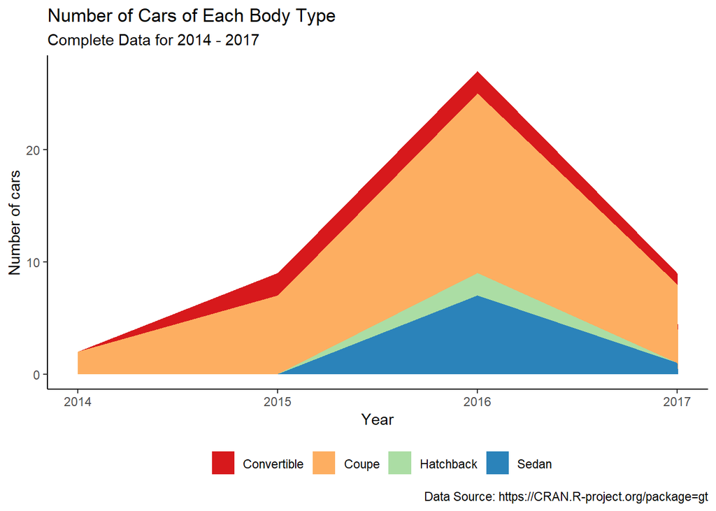

```r
(gt_car_area_plot1 <- my_gtcars1 |>
  ggplot() +
  geom_area(aes(x=year, y=total, fill=bdy_style)) +
  theme_classic() +
  theme(legend.position="bottom") +
  scale_x_continuous(breaks=seq(2014,2017,1)) +
  scale_fill_brewer(palette = "Spectral") +
  labs(x="Year", y="Number of cars", fill="",
       title="Number of Cars of Each Body Type",
       subtitle="Complete Data for 2014 - 2017",
       caption="Data Source: https://CRAN.R-project.org/package=gt"))
```

### **Key Points from Week 9**

**Rough Draft Proposals are due on Thursday 3/21 at 5:30 PM.**

**Data Management Skills - Some Review and Some New**

- summarizing number of observations by category using `n()`
- Using `sum(c_across())` to sum across rows
- Knowing how to *complete* data that is incomplete
- Next Week
  - HW 5 - Part 1 is due Wednesday, 3/27.
  - **Practice questions for Quiz 2 will be posted by Thursday 3/28 (Quiz is on Thu. 4/4).**
  - Managing and presenting geographic data in choropleth maps (Not on Quiz 2).

You may submit an ‘Engagement Question’ about each lecture until midnight on the day of the lecture. **A minimum of four submissions are required during the semester.**